# User Guide

## Introduction

#### PhenEndo is a data mining and visualization tool for studying endotypes targeted for questionnaire or other biomedical records. With its features and design it helps the user to develop its own medical data analysis application, as it provides a step-by-step guidance from getting the first feature simple statistics to advanced cluster analysis.

#### To make you confident with PhenEndo functionalities, we will walk you through the whole process by showing you a small example with our custom dataset, which can be downloaded here. The dataset contains 33 categorical and numerical attributes. To specify the features datatype, we also provide a second file, containing a name list of all categorical attributes.

## Upload Data

#### This tool supports numerical as well as categorical data, such as survey data. For this purpose, we recommend the user to upload two data files.

#### The first one contains the attributes (or features) which are going to be analyzed for every biomedical record.

#### The second one annotates the categorical features in the first dataset.

#### PhenEndo accepts .csv, .txt, .xlsx data files. To get an idea of the data format, please check our custom data.

## Data Visualization

#### Three types of data visualization are provided to help the user get first insights of the data.

### Heatmap

#### Here, we present a heatmap of the data entries, which are scaled between 1/(number of unique feature values) and 1. The y-axis represents the features and the x-axis the data items. For example, in our sample data attributes 5, 8 and 24 have lower values (the cells of the corresponding entries are mainly in the blue scale).

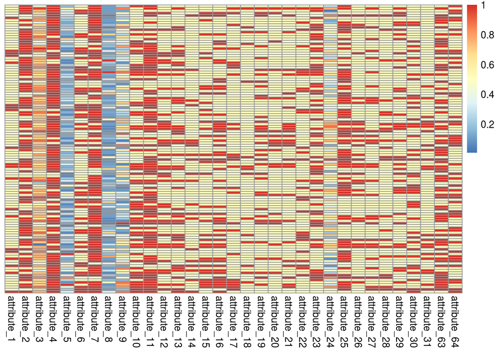

### Attribute Barplots

#### A barplot or a histogram of every attribute is provided, to describe its distribution structure. For example, in many of these plots one can see the imbalance in the binary variables, e.g. attribute_1, attribute_4 and attribute_7. These highly biased sets add to the noise in the data. On the other hand, if they co-occur they can be the deciding factor for the clustering algorithms. See next section on FAMD.

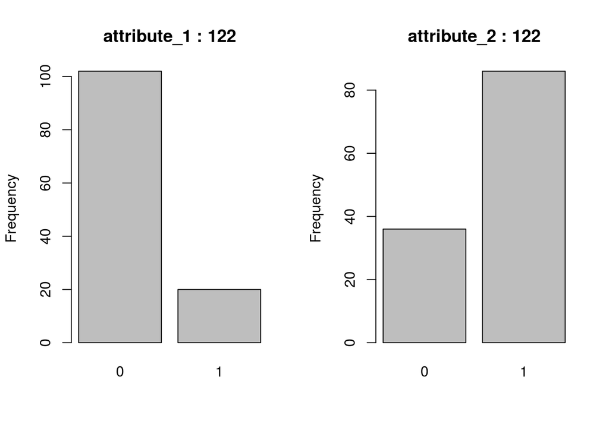

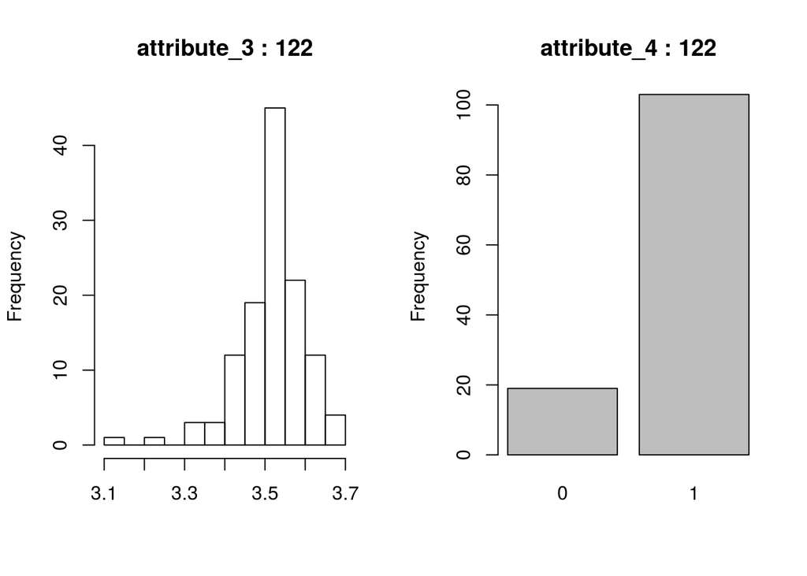

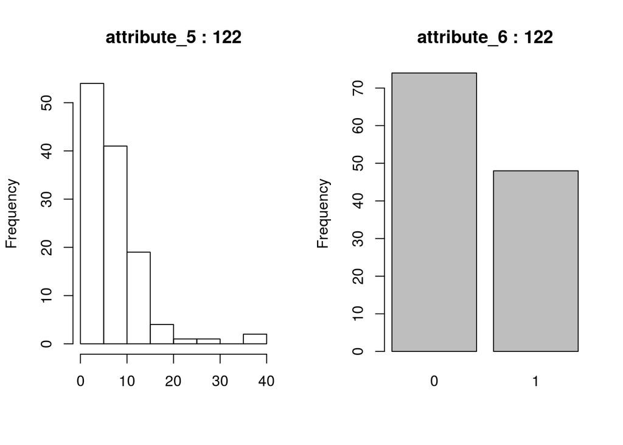

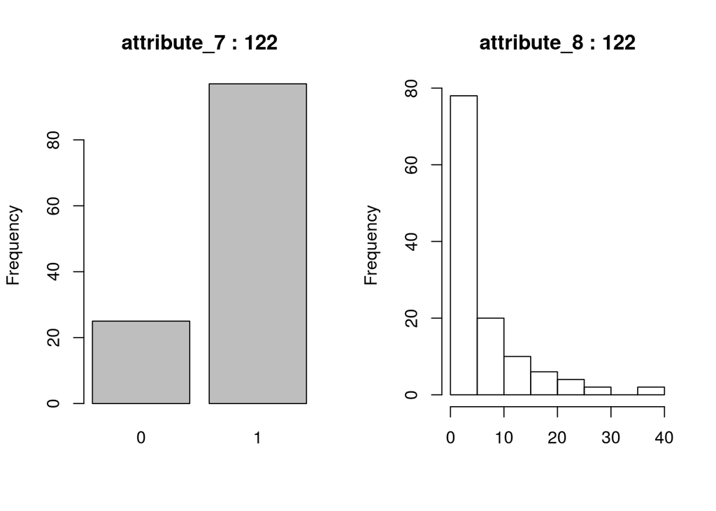

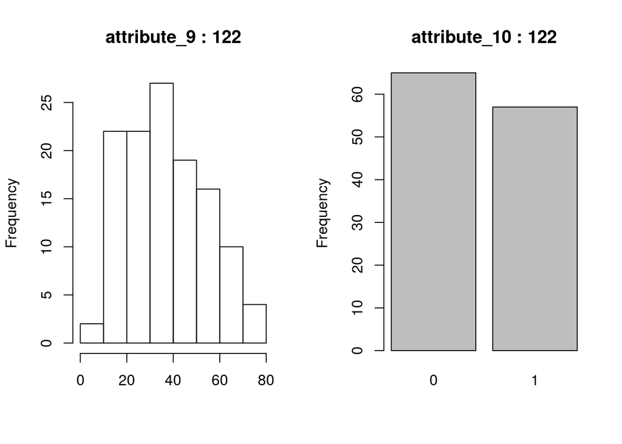

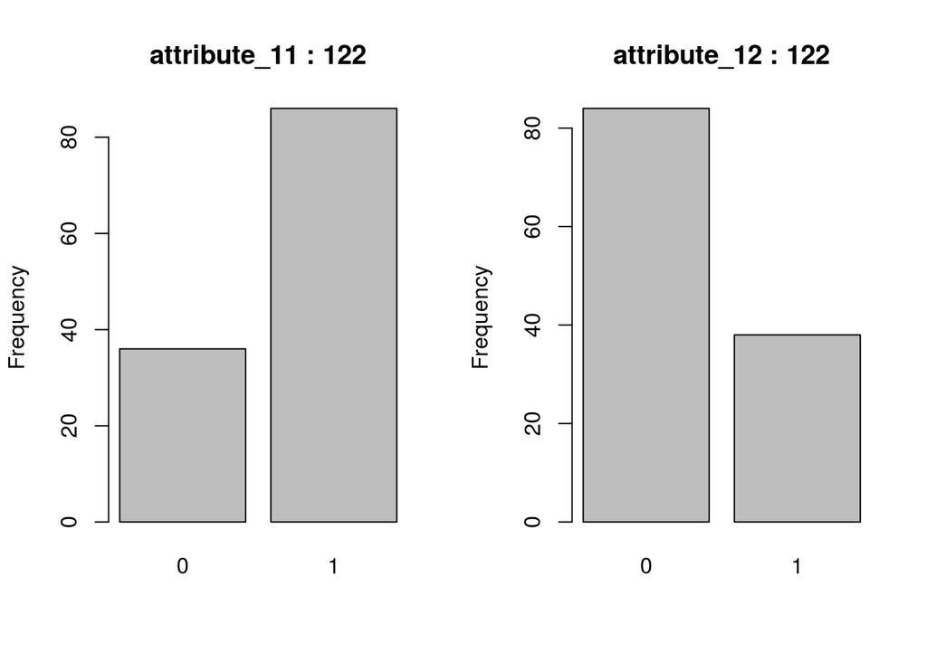

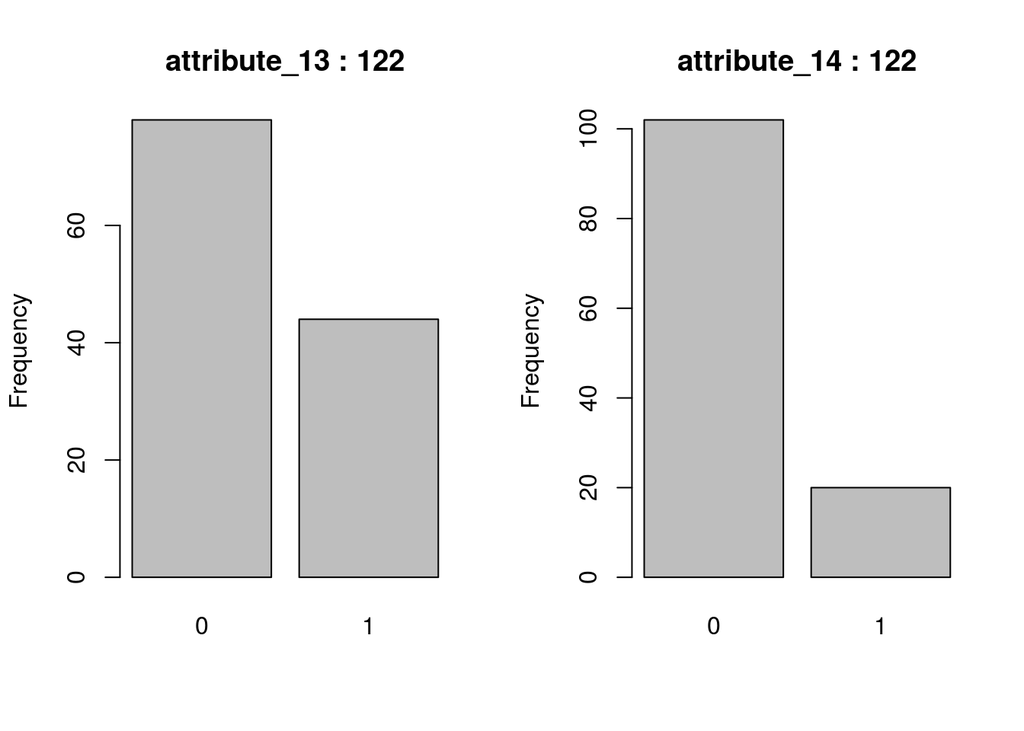

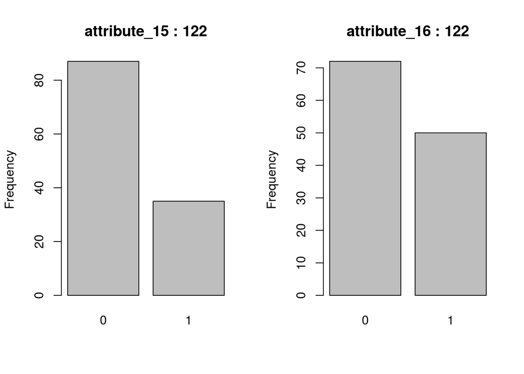

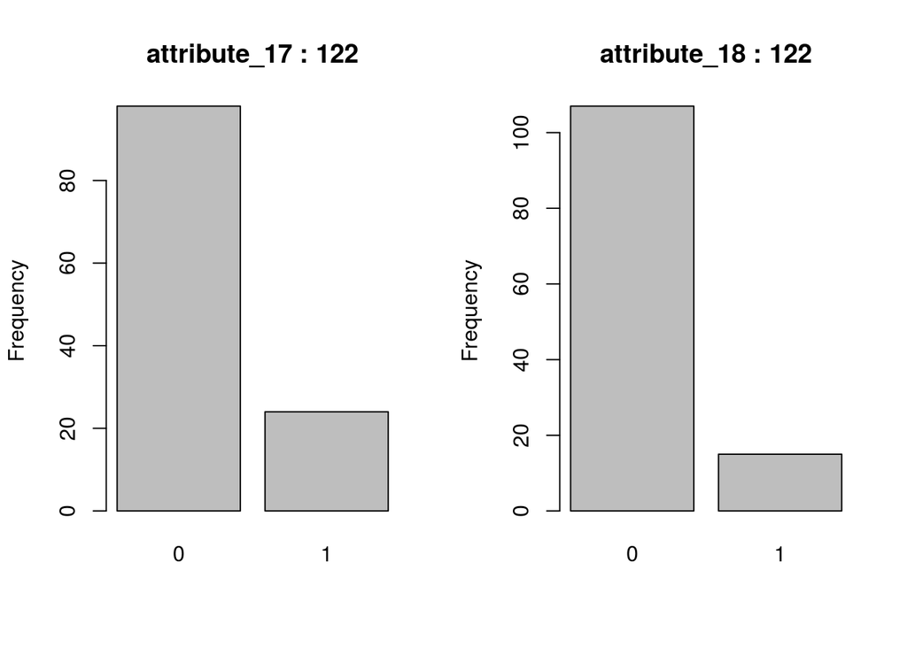

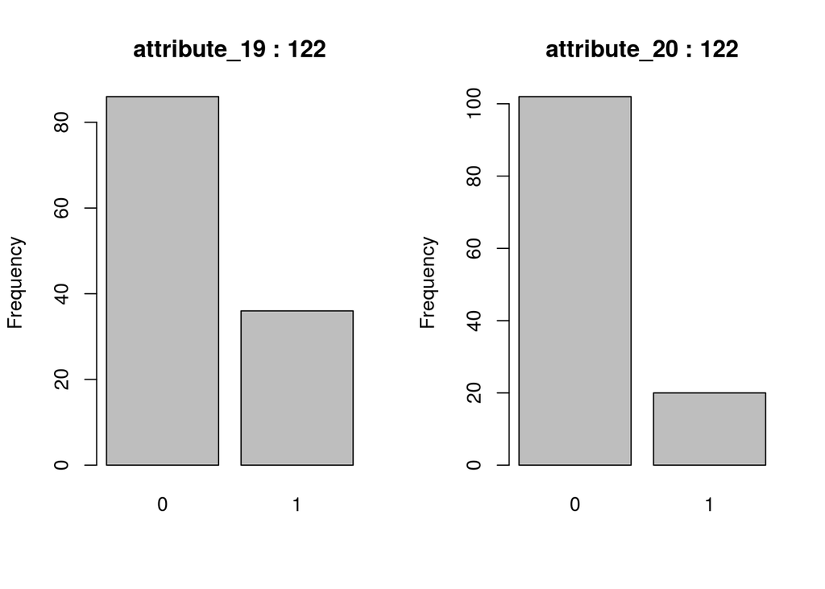

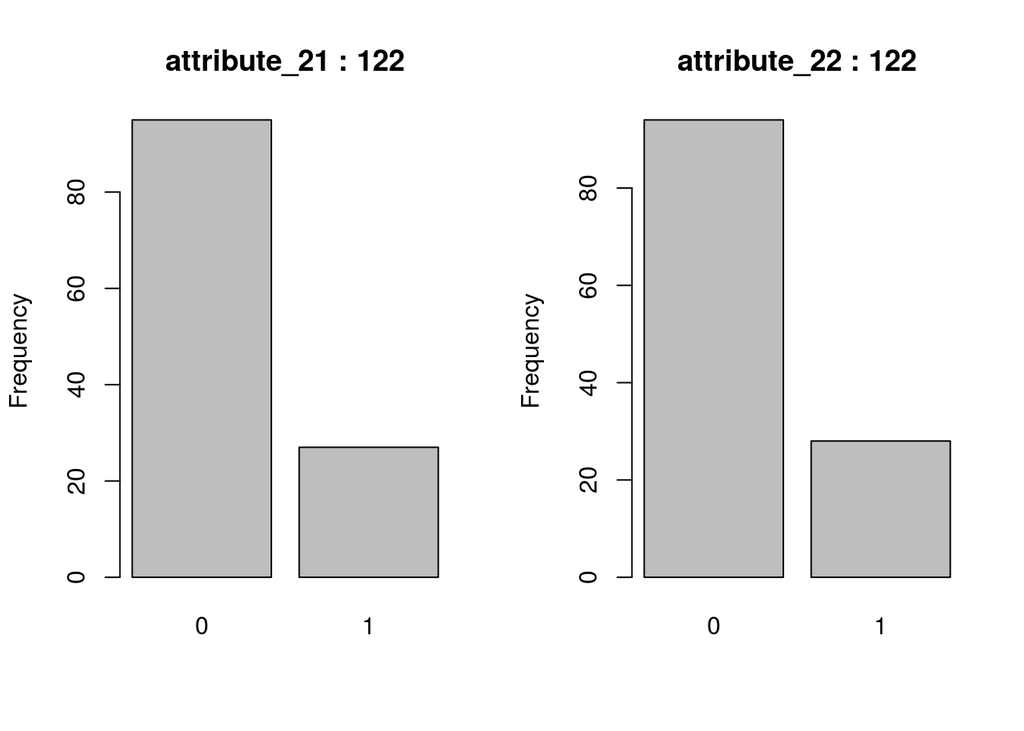

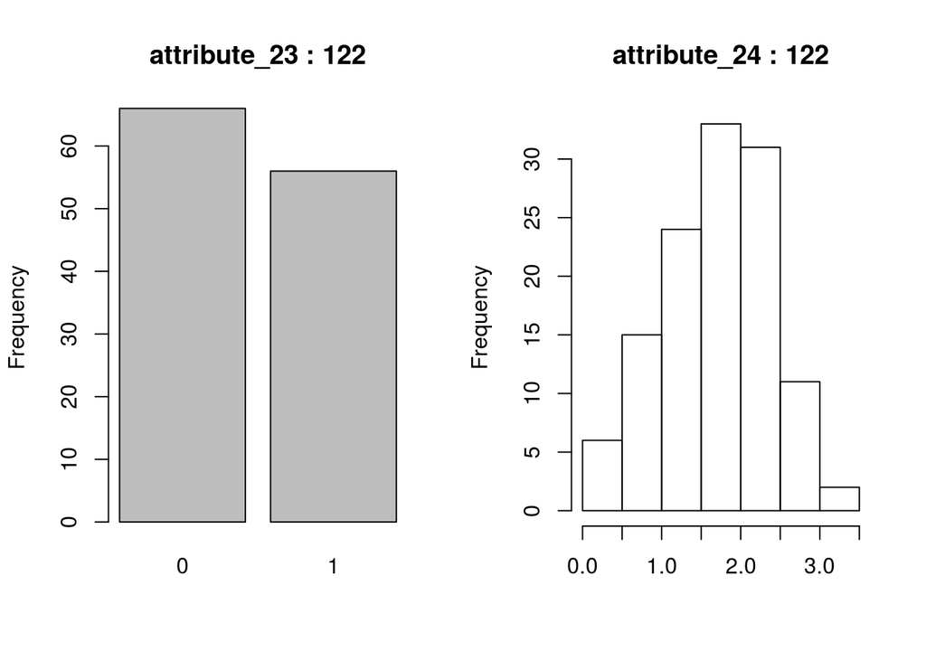

[5 more figures not shown]

### FAMD Plots

#### Factor Analysis for Mixed Data (FAMD) is a version of PCA, which considers the categorical features in the dataset. The generated plots study the relationship between the different features, projected on the two components, which have the greatest eigenvalues. In our case the first second components explain at most approx. 19% of the variance.

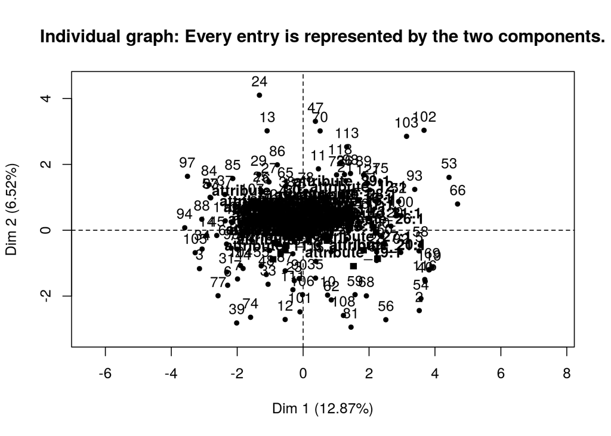

#### The quantitative plot indicates that some of the continuous features are dependent, e.g. it seems that attributes 8 and 5 are (perfectly) negative correlated.

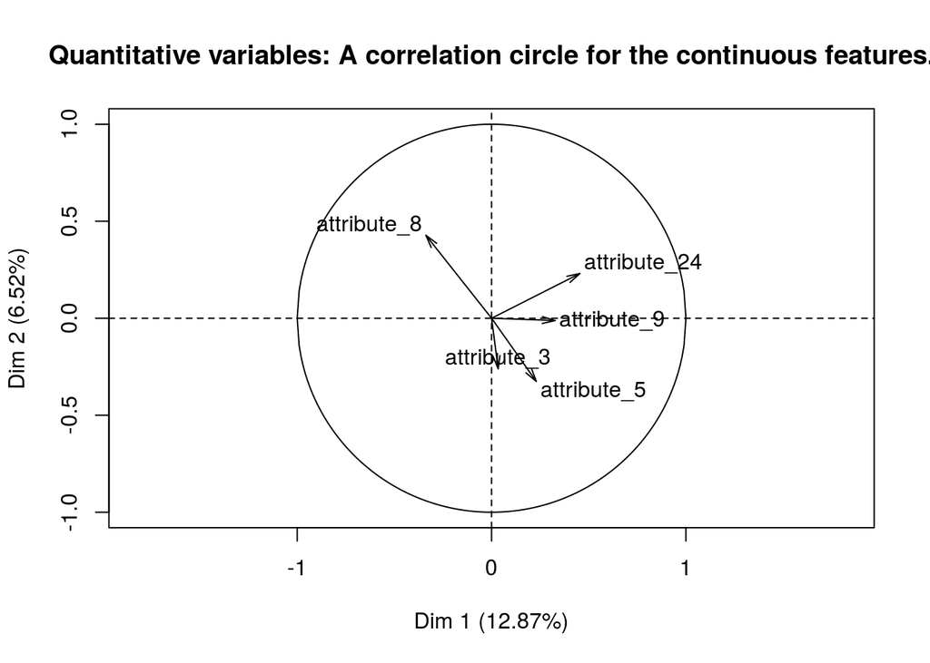

#### Our example suggests that the plot with qualitative variables is particularly interesting. If you notice that many of the levels on the right are with value 1. Showing that many attributes are dependent and presence of a certain attribute co-occur with other attributes.

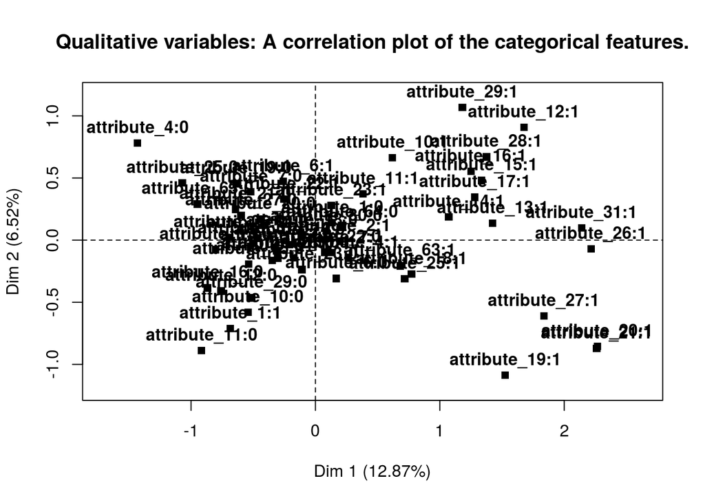

#### The correlation between all features (categorical and continuous) is represented in the following plot.

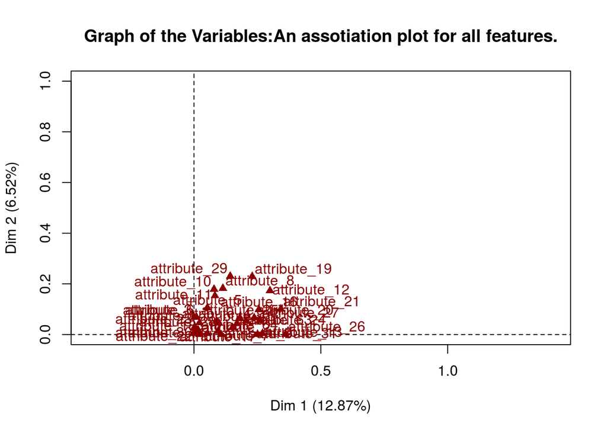

## Consensus Clustering

#### To determine the optimal number of clusters, Consensus Clustering is used. The data first is subsampled and afterwards is clustered several times with number of clusters ranging from 2 to a number given by the user. Each clustering is evaluated by generating a consensus matrix, whose entries store the proportion of clustering runs in which two items are clustered together. Note that for this experiment, hierarchical clustering with Ward.D2 clustering criterion is chosen. Moreover, the clustering distance is the Gower distance, which considers the presence of categorical features in the dataset. The output plots of this procedure help the user optimally determine the number of clusters from the dataset.

### Consensus Matrix for each Clustering

#### The consensus clustering algorithm outputs a consensus matrix heatmap, whose x and y axis represent the data observations. The color scale ranges from white to blue, such that white stands for 0 matrix entry value (the items are never clustered together) and blue for 1 (the items are always clustered together). In the plot we can see a consensus matrix for three clusters, resulting from our sample data.

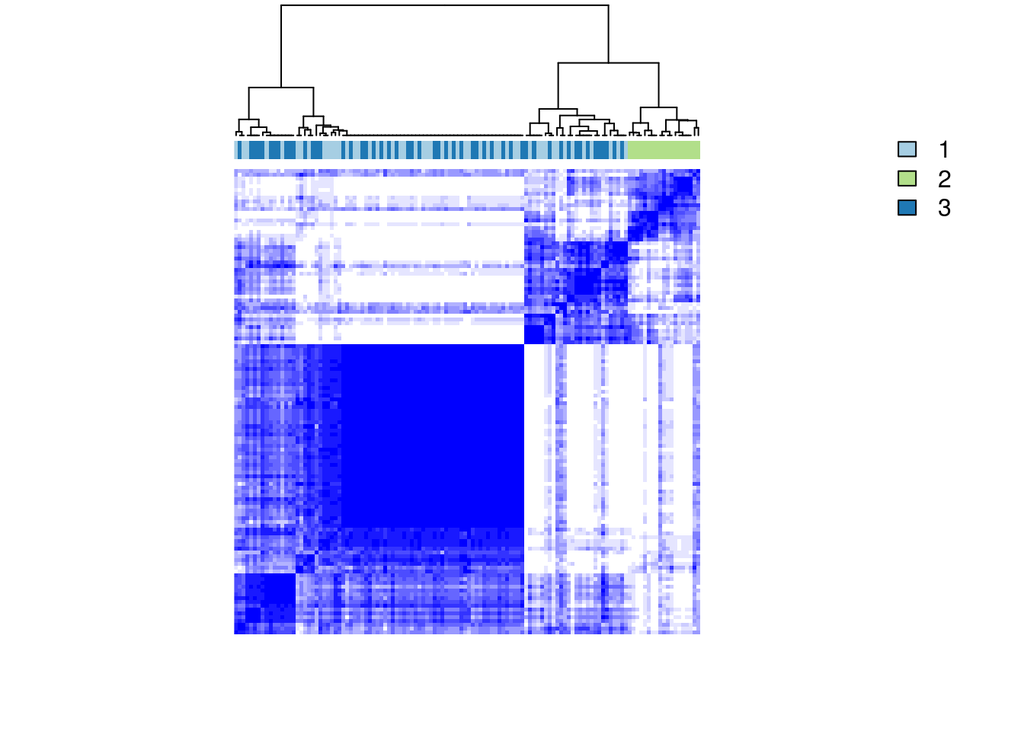

### Delta Plot

#### The cummulative distrbution of the consensus matrix entries (CDF) is another useful statistic for evaluating the calculated clusters and is used for generating the delta plot, which shows the area under the CDF curve for each clustering. Thus, it allows the user to observe the relative increase in consensus (y-axis) and determine the number of clusters K at which there is no appreciable increase. After the true K is reached there should be no significant change in the area under the CDF. In our example, a hierarchical clustering with 6 modes is a possible candidate.

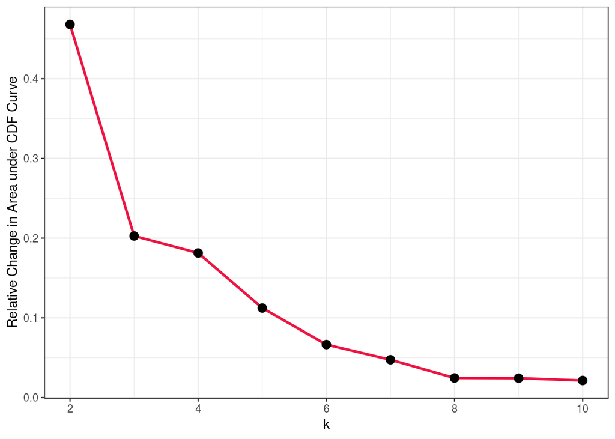

## Clustering Signature

#### The last functionality in PhenEndo studies the attributes importance for the cluster seperation. Therefore, we fit a mutlinomial GLM with covariates the data and response the assigned clusters. The carried-out cluster analysis suggests that the optimal number of clusters is 6. Therefore, we set up the experience for 6 labels, corresponding to the clusters ids.

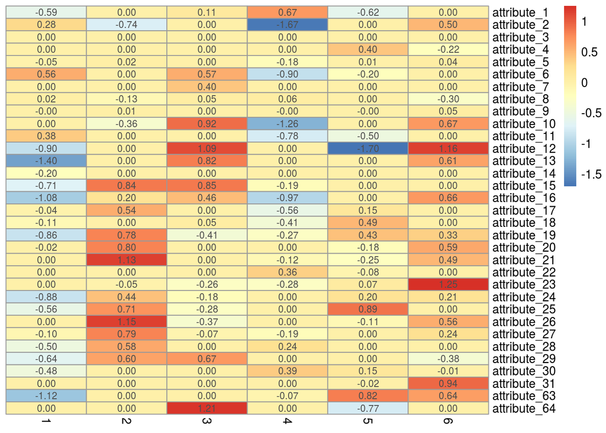

| key | statistic | p.value | parameter | method |
| --- | --- | --- | --- | --- |
| attribute_1 | 14.261601 | 0.0140304 | 5 | Kruskal-Wallis rank sum test |
| attribute_10 | 28.943173 | 0.0000238 | 5 | Kruskal-Wallis rank sum test |
| attribute_11 | 16.834940 | 0.0048237 | 5 | Kruskal-Wallis rank sum test |
| attribute_12 | 63.910812 | 0.0000000 | 5 | Kruskal-Wallis rank sum test |
| attribute_13 | 36.533574 | 0.0000007 | 5 | Kruskal-Wallis rank sum test |
| attribute_14 | 9.598224 | 0.0874535 | 5 | Kruskal-Wallis rank sum test |
| attribute_15 | 32.583314 | 0.0000046 | 5 | Kruskal-Wallis rank sum test |
| attribute_16 | 42.113664 | 0.0000001 | 5 | Kruskal-Wallis rank sum test |
| attribute_17 | 11.082330 | 0.0497718 | 5 | Kruskal-Wallis rank sum test |
| attribute_18 | 10.987587 | 0.0516266 | 5 | Kruskal-Wallis rank sum test |
| attribute_19 | 41.576018 | 0.0000001 | 5 | Kruskal-Wallis rank sum test |
| attribute_2 | 27.198909 | 0.0000522 | 5 | Kruskal-Wallis rank sum test |
| attribute_20 | 38.667277 | 0.0000003 | 5 | Kruskal-Wallis rank sum test |
| attribute_21 | 51.703542 | 0.0000000 | 5 | Kruskal-Wallis rank sum test |
| attribute_22 | 2.104142 | 0.8345554 | 5 | Kruskal-Wallis rank sum test |
| attribute_23 | 11.233956 | 0.0469336 | 5 | Kruskal-Wallis rank sum test |
| attribute_24 | 25.668841 | 0.0001034 | 5 | Kruskal-Wallis rank sum test |
| attribute_25 | 33.799667 | 0.0000026 | 5 | Kruskal-Wallis rank sum test |
| attribute_26 | 48.116439 | 0.0000000 | 5 | Kruskal-Wallis rank sum test |
| attribute_27 | 31.595013 | 0.0000071 | 5 | Kruskal-Wallis rank sum test |
| attribute_28 | 17.666000 | 0.0033955 | 5 | Kruskal-Wallis rank sum test |
| attribute_29 | 24.246881 | 0.0001946 | 5 | Kruskal-Wallis rank sum test |
| attribute_3 | 3.765932 | 0.5835836 | 5 | Kruskal-Wallis rank sum test |
| attribute_30 | 6.342491 | 0.2743047 | 5 | Kruskal-Wallis rank sum test |
| attribute_31 | 29.432331 | 0.0000191 | 5 | Kruskal-Wallis rank sum test |
| attribute_4 | 17.092718 | 0.0043273 | 5 | Kruskal-Wallis rank sum test |
| attribute_5 | 12.070488 | 0.0338346 | 5 | Kruskal-Wallis rank sum test |
| attribute_6 | 14.899664 | 0.0107998 | 5 | Kruskal-Wallis rank sum test |
| attribute_63 | 30.108693 | 0.0000140 | 5 | Kruskal-Wallis rank sum test |
| attribute_64 | 15.612814 | 0.0080410 | 5 | Kruskal-Wallis rank sum test |
| attribute_7 | 3.011093 | 0.6982754 | 5 | Kruskal-Wallis rank sum test |
| attribute_8 | 12.001788 | 0.0347633 | 5 | Kruskal-Wallis rank sum test |
| attribute_9 | 10.079832 | 0.0730046 | 5 | Kruskal-Wallis rank sum test |